# Plotting in R

### 2.2.2 Scatter plot

We plot price (y-axis) versus weight (x-axis) in `ggplot`, exactly like we did in the initial base plot example.

**Plot price (y-axis) versus weight (x-axis)**:

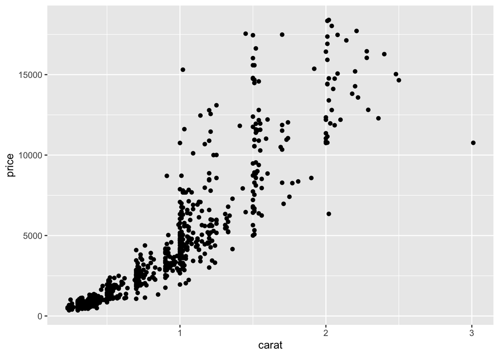

```r
ggplot(diam, mapping = aes(x=carat, y = price)) +
  geom_point()
```

**Plot price (y-axis) versus weight (x-axis), log-transformed x- & y-axis, fix point colour, add a trend line:**

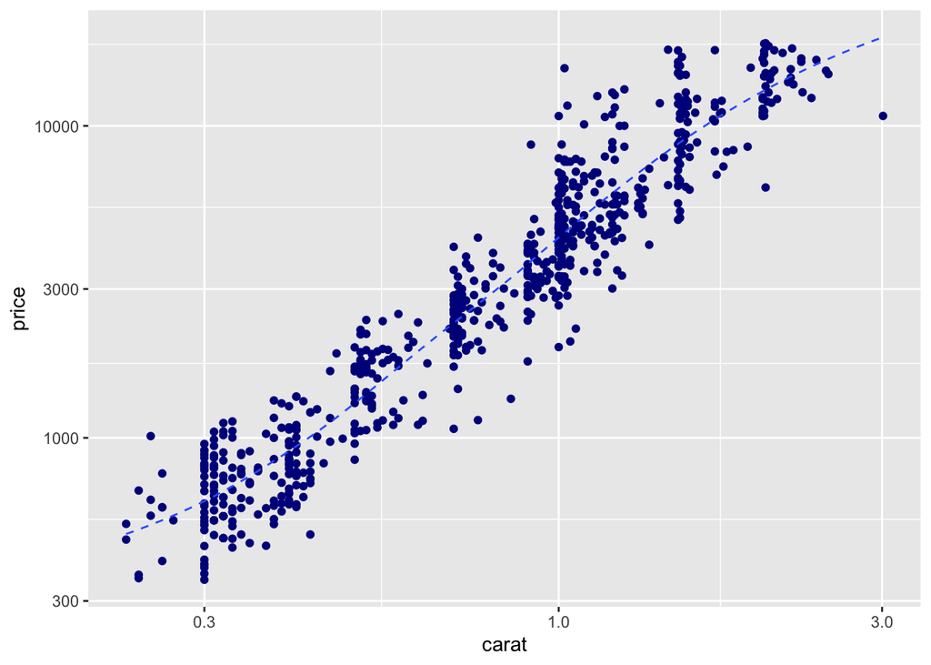

```r
ggplot(diam, mapping = aes(x=carat, y = price)) +
  geom_point(col = "darkblue") +
  geom_smooth(linetype = "dashed", size = 0.5, alpha = .4, se = FALSE) +
  scale_x_log10() +
  scale_y_log10()
```

**Plot price (y-axis) versus weight (x-axis), colour according to cut, log-transformed x- & y-axis:**

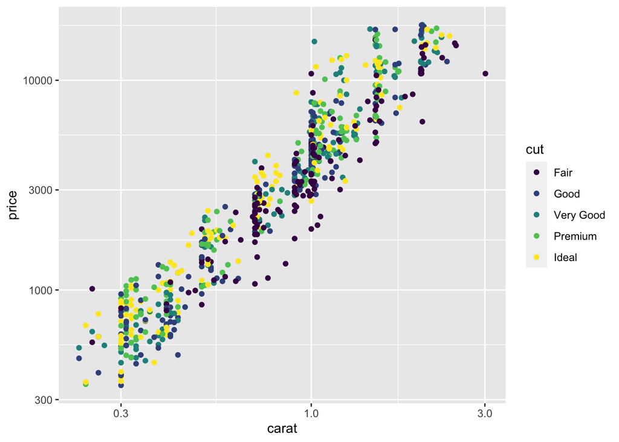

```r
ggplot(diam, mapping = aes(x=carat, y = price, col = cut)) +
  geom_point() +
  scale_x_log10() +
  scale_y_log10()
```

### 2.2.3 Boxplots & friends

Boxplots summarize a metric measurement variable and visually represent location and spread of the data using quantiles like the 25%-quantile, the 50%-quantile (median) and the 75%-quantile.

**Plot price distribution per cut-group, log-transformed y-axis:**

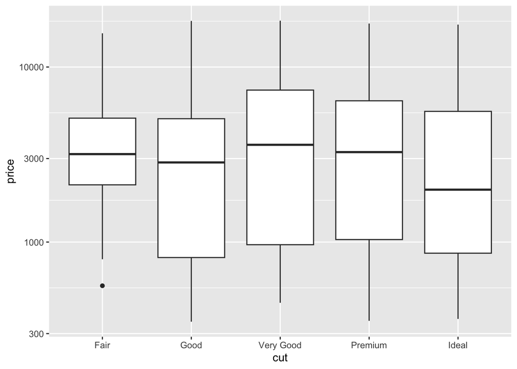

```r
ggplot(diam, aes(x = cut, y = price)) +
  geom_boxplot() +
  scale_y_log10()
```

**Plot price distribution as violin plot per cut-group for all diamonds in `diam` with weight less than 1.75 carat on log-scale. Separate plots as per diamond colour:**

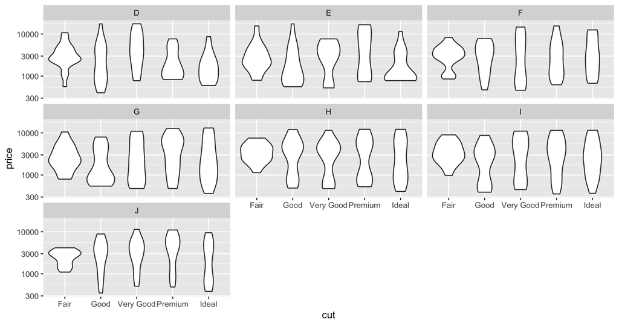

```r
# dplyr pipeline followed by ggplot pipeline
diam |>
  dplyr::filter(carat < 1.75) |>
  ggplot(aes(x = cut, y = price)) +
    geom_violin() +
    scale_y_log10() +
    facet_wrap(facets = vars(color))
```

The `facet_wrap` and `facet_grid` functions allow to have sub-panels in one big plot. These are informative when a relationship between two variables changes depending on a third variable.

### 2.2.4 Function graph

Sometimes, you quickly want to plot a graph of a function, e.g. you want to visualize $y = \sqrt x · x - 1$. As you have seen, in `ggplot2` you normally start with data that resides in a dataframe but for a function graph the relation between x and y is described by the function equation and you do not need any data. For this special requirement there is `geom_function`. A dataframe is not required, it is enough to specify the requested range on the x-axis.

The following plots shows the initially given function in the range from 0 to 5. For reference, we add the bisecting line

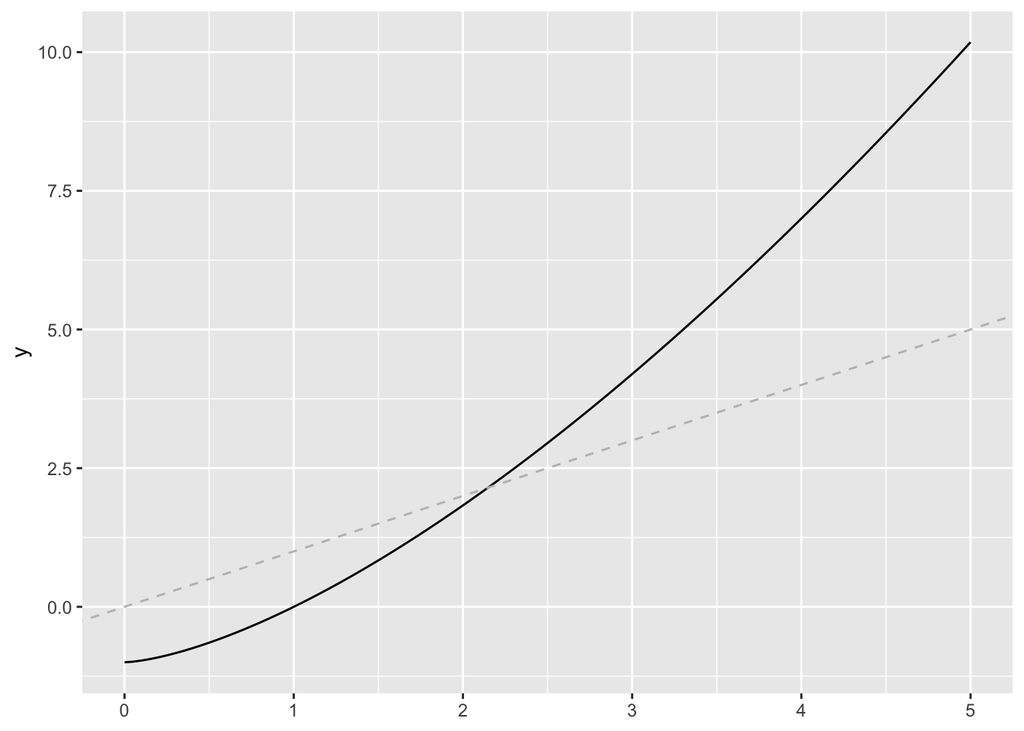

```r
 ggplot() + xlim(c(0, 5)) +
  geom_function(fun = \(x) sqrt(x) * x - 1) +
  geom_abline(intercept = 0, slope = 1, colour = "grey", linetype = "dashed")
```

## 2.3 Further Material

There is quite some high-quality material about `ggplot2` available online:

1. [`ggplot2`’s package website](https://ggplot2.tidyverse.org/) is worth reading (and viewing), in particular have a look at the section [Learning `ggplot2`](https://ggplot2.tidyverse.org/#learning-ggplot2) that proposes different learning paths to master `ggplot2`.
2. We (again) recommend chapters within the book «R for Data Science» which is online available freely. The two relevant chapters are
   - https://r4ds.hadley.nz/data-visualize.html
   - https://r4ds.hadley.nz/communication.html.